# test_scrolly_map

## Klimakollektiv Scrollytelling

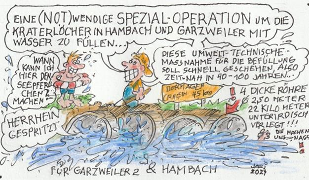

## Rhein bei Chempark Dormagen

Das Rheintal ist sehr eng verbunden mit den Wassersystemen der Niederlande, z.B. mit dem großen Mündungsgebiet von Rhein, Maas und IJssel. Daher muss die Europäische Wasser- rahmenrichtlinie (2000/60/EG; EU-WRRL) unbedingt und unverzüglich umgesetzt werden.

Rheinwasser enthält große Mengen von gesundheitsgefährdenden Medikamenten-, Kohlen- wasserstoff- und Düngemittelresten sowie weiterer Chemikalien und Mikroplastik. All diese Schadstoffe haben auch in geringen Konzentrationen nichts in den zukünftigen Seen und Naturschutzgebieten zu suchen. Es ist keine entsprechende Reinigungsstufe vorgesehen, um den Schadstoffeintrag ins Ökosystem zu vermeiden; dies muss umgehend vor einer Geneh- migung eingeplant werden.

## Entnahmebauwerk bei “Haus Piwip”

Das Entnahmebauwerk liegt direkt am Prallhang, nur wenig rheinabwärts vom Chempark Dormagen, und dringt tief in den Grundwasserkörper ein. Die Folgen sind nicht ausreichend untersucht und stellen eine Gefährdung dar.

Zur Quantität der Wasserentnahme:

Der Klimawandel wird uns stark schwankende Niederschlagsmengen bringen. Dadurch wird die Entnahmemenge aus dem Rhein erheblich von den Planungen abweichen. Ebenso wird das Abschmelzen der Gletscher sehr stark dazu beitragen, dass weniger Rheinwasser zur Verfügung stehen wird. Nach Schätzungen von Glaziologen ist die Quelle des Rheins, der vom Gletscherwasser lebt, in 30 bis 40 Jahren versiegt.

Auch die Bedürfnisse der Schifffahrt sowie die Trinkwasser-Gewinnung in den Niederlanden müssen berücksichtigt werden. Bei zu geringem Rheinwasserstand strömt bei Flut viel mehr Wasser in den Mündungstrichter der großen Flüsse und versalzt dadurch die Trinkwasserbrunnen, die dort hauptsächlich Rheinuferfiltrat ziehen.

Experten gehen davon aus, dass aus o.g. Gründen wesentlich weniger als die von RWE geplanten 18m3/sec entnommen werden können.

Das Thema „Verdunstung“ wird nur an einer Stelle in einer Matrix erwähnt, aber nicht weiter untersucht oder quantifiziert.

## Rheinwassertransportleitung z.B. Wald-NSG bei Knechtsteden

Zum Bau der RWTL wird ein ca. 70m breiter und letztendlich 45 km langer Streifen als „Bau- platz“ benötigt. Für die Trasse müssen Biotope durchschnitten, Bäume gefällt und grundwas- serführende Schichten durchtrennt werden. Zu errichtende Gebäude dringen tief in den Grundwasserkörper ein.  
Die Folgen sind nicht ausreichend untersucht und stellen eine Gefährdung dar.

Mögliche Beschädigung der Rohrleitung  
Durch das fließende Wasser entsteht ein Abrieb der Kunststoffbeschichtung der wasser- führenden Leitungen, wodurch weitere Mikroplastikpartikel in den See gespült werden. Auch das darf nicht geschehen.

Des weiteren kann durch die geringe Verlegetiefe bzw. Überdekkung der RWTL in landwirt- schaftlich genutzten Flächen durch das Überfahren mit landwirtschaftlichen Großgeräten, die beladen bis zu 50 t wiegen, eine Beschädigung eintreten.

## Verteilerbauwerk Allrath

Von hier aus werden zwei Rohre in Richtung Hambacher Tagebau, eins zum Tagebau Garzweiler und möglicherweise eins in Richtung der Naturgebiete Schwalm-Nette verlegt.

## Die Seen bei Inden, Hambach und Garzweiler

Aus dem unter (1) Gesagten ergibt sich Grund zur Sorge, dass diese Löcher eher nie als in sehr optimistisch prognostizierten 40 Jahren mit Wasser gefüllt sein werden; nachgebesserte Zeitangaben sprechen mittlerweile von 70 Jahren. Aber auch das wird zu kurz bemessen sein.

In der Grube lagern große Mengen an Schadstoffen, vor allem auch das Säure bildende Pyrit. Geplant ist zwar ein Überdecken dieser Schicht mit einer immens großen Kalkmenge; aber es ist unbestritten, dass sich am Grund des Sees eine sog. Todeszone vor allem aus giftigen Be- standteilen im Erdreich und entstandener Schwefelsäure entwickeln wird. Das Wasser wird in die umgebenden Böschungen hineindiffundieren und dort das Pyrit bzw. das entstehende Sulfat aus dem Lockergestein auswaschen und den derzeit zur Trinkwassergewinnung genutzten Grundwasserleiter 8 unbrauchbar machen (Sulfat z.T. >1000 mg/l erwartet).

Ob die Seewasserqualität in absehbarer Zukunft eine Freizeitnutzung mit Wasserkontakt zu- lässt, ist sehr zu hinterfragen. Wir sehen auch im ostdeutschen Braunkohlerevier, dass z.T. ständig zur Neutralisierung gekalkt werden bzw. der Zugang zum Wasser verwehrt werden muss. Auch das aufsteigende Grundwasser rundherum reagiert mit dem oxidierten Pyrit zu H2SO4 und trägt diese Schwefelsäure mit nach oben.

(Anm.: Diese Oxidation findet auch im gewachsenen Erdreich statt, weil dort, wo das Grundwasser ehemals gesümpft wurde, Sauerstoff Zutritt zum Pyrit hatte.)

Außerdem wird sich als zweites Verwitterungsprodukt des Pyrits in großen Mengen Ocker bilden, dessen Entfernung aus dem Wasser und Entsorgung an keiner Stelle mitgeplant wurde.

Vergleicht man die unglaubliche Tiefe der Seen mit der viel geringeren Tiefe der Restseen in der Lausitz und die sich ständig ereignenden Hangrutschungen dort, erscheint es mehr als fraglich, ob es ausreicht, die Hänge wie geplant nur im oberen Bereich auf ein Gefälle von 1:5 oder 1:7 auszulegen, wenn in unteren Bereichen wesentlich steilere Böschungen und die aufgrund des unterschiedlichen Materials und der stattfindenden Durchweichung großen Rutschungsgefahren bestehen bleiben.

## Erdbebengefahrenzone z.B. Peringsmaar

WDR am 28.08.2024: “Leichtes Erdbeben bei Bergheim. Der Erdstoß wurde in 1 km Tiefe aus- gelöst, auf der Fläche des ehemaligen Tagebaus Fortuna Garsdorf bei Bergheim-Paffendorf”

Das Braunkohlegebiet steht geologisch in engem Zusammenhang mit der Erdbebenzone III im Aachener Raum. Dies wird noch bestärkt durch alte Bergbaustollen, die aus einem älteren Bergbau stammend, sich z.B. unterhalb des Hambacher Tagebaus befinden.

Diesbezügliche Gefährdungen - z.B. die Standfestigkeit der Grube oder die „Dichtheit des Seegrundes“ - werden an keiner Stelle thematisiert und/oder untersucht.

## Gefährdung der Feuchtgebiete z.B. Schwalm a.d. Pannenmühle

Ein Teil des Rheinwassers soll bis die Füllhöhe des Garzweiler Tagebaus erreicht wird, direkt in die Feuchtgebiete Schwalm/Nette geleitet werden, um diese zu erhalten.

Danach soll die Niers aus dem Überlauf des Garzweiler Sees durch den sog. „Nierscanyon“ gespeist werden. Durch beide Einspeisungen werden oben schon beschriebene Schadstoffe in diese Biotope gelangen und ebenfalls das Grundwasser kontaminieren.

Allerdings ist die Zuleitung des Rheinwassers bis zu den NSGen nicht mit beantragt. Aus Kreisen des BUND wurde berichtet, dass ebenfalls die Möglichkeit diskutiert wird, die Feuchtgebiete ebenfalls aus der angedachten Trinkwasserleitung (s.u. 7) aus dem Binsheimer Feld zu speisen.

## Gefährdungen der Trinkwasserversorgung z.B. im Binsheimer Feld

Das Land NRW ist sehr stark betroffen von großen wasserwirtschaftlichen und -technischen Herausforderungen, die sich sowohl auf die Bausubstanz, die Landwirtschaft und die Versor gung der Bevölkerung mit sauberem Trinkwasser auswirken. Linksrheinisch gibt es riesige Sümpfungsgebiete durch den Braun- und Steinkohleabbau, die Salzbergwerke sowie Verän derungen des Grundwasserspiegels durch den großflächigen Kiesabbau. Zwischen diesen Standorten zeigen sich unerklärliche Grundwasseranstiege. Ohne eine Gesamtbetrachtung darf nicht weiter in den Wasserhaushalt der Region eingegriffen werden. Schließlich hat das Rheinische Revier durch die Sümpfungsmaßnahmen ein Grundwasserdefizit von 20 Mrd. Kubikmeter Wasser. Laut einer Untersuchung verliert Deutschland im globalen Ranking das meiste Wasser (siehe Grace-Mission des Global Institute for Water Security 2022).

Wie vorstehend beschrieben, versauert teilweise auch das Grundwasser und damit werden im Laufe der Zeit fast alle Trinkwasserbrunnen rund um die Tagebaue unbrauchbar – wahr scheinlich betroffen auch die Privatbrauer Bolten in Korschenbroich (N 51.18346, E 6.49947). Außerdem wird als zweites Verwitterungsprodukt des Pyrits in großen Mengen Ocker gebil det, dessen Entfernung aus dem Wasser und Entsorgung an keiner Stelle mitgeplant wurde.

Eine zusätzliche Gefährdung entsteht durch die Mobilisierung von Altlasten aus Böschungs bereichen bei steigendem Grundwasser und dessen Verschmutzung. Die Verfüllung der Natur(schutz)gebiete mit ungeeignetem Wasser wirkt sich auch dort auf die Trinkwasserqualität aus. Das nach einem Urteil des Europäischen Gerichtshofes (EuGH 2020 / Rs. C.535/18) geltende Verschlechterungsverbot für Grundwasser wird missachtet. Wasser ist das elementar lebenswichtigste Gut und wird so in unverantwortlicher Weise gefährdet. Weitere Gefährdungen durch die angedachte Trinkwasserleitung aus dem Binsheimer Feld nach Mönchengladbach und andere Orte

Wie bei der RWTL werden auch beim Bau dieser Trinkwasserleitung Biotope und Grundwas serschichten durchschnitten. Die Auswirkungen auf die Grundwasserströme im Rhein-Maas Niers-Gebiet werden nicht untersucht.

Geplant ist u.a. die Entnahme von Rheinuferfiltrat. Fraglich ist, ob das Rheinuferfiltrat wegen der Folgen des Klimawandels in ausreichender Menge zur Verfügung stehen wird und ob seine Schadstoffbelastung bei sinkenden Rheinwasserständen und den dann zu erwartenden höheren Konzentrationen eine Verarbeitung zu Trinkwasser zuläßt.

## Rechtliche Fragen und Probleme z.B. Ende “Garzweiler-Leitung” und Einleitungsbauwerk bei Elsdorf

Genehmigungsverfahren Das Verlegen einer Rohrfernleitung unterliegt normalerweise der Rohrfernleitungsverord nung. Warum darf RWE hier eine Genehmigung nach Bergrecht beantragen? Bislang ist nur Entnahme und Einleitung nach Bergrecht möglich; die Leitungen selbst sind durch kommu nale Entscheidungen zu genehmigen Unsere Forderung: Es muss ein gemeinsames Genehmigungsverfahren zur Entnahme und Einleitung geben; denn alle Probleme und Gefahren, die im Kontext stehen, müssen zwingend zusammen gesehen und in der Planung zusammen bedacht werden. Aus dem Antrag ist nicht klar ersichtlich, was die RWE Power AG denn nun beantragt. Der Titel des Antrags lässt vermuten: es geht um den Bau der Rheinwassertransportleitung. Die beantragten Genehmigungen beziehen sich sehr häufig auf wasserrechtliche Themen. Die angefügten Dokumente enthalten dann die Bauabschnitte der Pipeline. Sollte ein Genehmigungsverfahren in diesem relevanten Ausmaß nicht konkreter und für Außenstehende klar verständlich sein? Zumal für die Genehmigungen in unterschiedlichen Bereichen schließlich auch Beantragungen bei unterschiedlichen Behörden von Nöten sind. Des weiteren stellt sich die Frage: Warum ist die Bergbaubehörde für wasserrechtliche Genehmigungen zuständig? Insbesondere ergeben sich folgende Problemlagen:

## Rechtliche Fragen und Probleme z.B. Ende “Garzweiler-Leitung” und Einleitungsbauwerk bei Elsdorf

Die Teilgenehmigungen zum Bau der RWTL und der Wasserentnahme bei Dormagen werden beantragt, ohne die wasserrechtliche Genehmigung zur Einleitung des Rheinwassers in die Tagebaue und die Feuchtbiotope Schwalm/Nette gleichzeitig mit zu beantragen. Durch diese Vorwegnahme werden wieder Sachzwänge geschaffen, die letztendlich zu der Einleitung des Rheinwassers in die Braunkohlegruben und die Schutzgebiete führen. Es ist bislang nicht ersichtlich, wie die RWTL von Garzweiler aus weitergebaut werden soll. (N 51.05089, E 6.56347 = Ende der beantragten Trassenführung Richtung Garzweiler und NSGs)

## Verschlechterungsverbot z.B. Korschenbroich / Brauerei Bolten

Wie vorstehend beschrieben, versauert teilweise auch das Grundwasser und damit werden im Laufe der Zeit fast alle Trinkwasserbrunnen rund um die Tagebaue unbrauchbar. Siehe unter 7 die Problematik der Trinkwasserbrunnen am Beispiel Korchenbroich / Bolten. Außerdem wird sich als zweites Verwitterungsprodukt des Pyrits in großen Mengen Ocker bilden, dessen Entfernung aus dem Wasser und dessen Entsorgung an keiner Stelle mitge plant wurde. Eine zusätzliche Gefährdung entsteht durch die Mobilisierung von Altlasten aus Böschungs bereichen bei steigendem Grundwasser und dessen Verschmutzung. Die Verfüllung der Natur(schutz)gebiete mit ungeeignetem Wasser wirkt sich auch dort auf die Trinkwasser qualität aus. Das nach einem Urteil des Europäischen Gerichtshofes (EuGH 2020 / Rs. C.535/18) geltende Verschlechterungsverbot für Grundwasser wird missachtet

[interactive chart not shown]